# 分類詞及實體名詞接受度調查準備

陳紹慶

2021-04-08

## 分類詞來源

賴宛君 (2011)、陳羿如與何萬順(2020)的61項分類詞，其中26項表徵物件形狀。田意民等人(2002)的九項分類詞，其中七項符合何萬順等人的形狀分類，「個」與「條」屬於「分離性」分類詞。

## 分類詞及名詞之語料

根據26項表徵物件形狀的分類詞，我們從平衡語料庫4.0(CKIP 1999)查詢語料並下載整理，各項分類詞的原始語料存於獨立文字檔，以漢語拼音命名。原始語料篩選出Nf緊接Na的條目，條目內取出分類詞及名詞，範例如下段。構成分類詞片語存入`selecting_[classifier name]_terms.txt`的純文字檔案。

```
一頂假髮
一朵桂花
一根拐杖
```

### 目標研究實驗材料整理

田意民等人(2002)選擇的名詞來自平衡語料庫3.0(CKIP, 1995)，語料來源與條目數量和目前學術界使用的平衡語料庫4.0(CKIP 1999)有差距。首先檢視田意民等人的研究一選用的分類詞及名詞，與平衡語料庫4.0抽出的分類詞片語之對應狀況。

| WORD | POS | FREQ | RANK | 條 | 枝 | 根 | 張 | 面 | 片 | 個 | 顆 | 粒 |
| --- | --- | --- | --- | --- | --- | --- | --- | --- | --- | --- | --- | --- |
| 肋骨 | NA | NA | NA |  |  | V |  |  |  |  |  |  |
| 胡瓜 | NA | NA | NA |  |  |  |  |  |  |  |  |  |
| 魚刺 | NA | NA | NA |  |  |  |  |  |  |  |  |  |
| 廁紙 | NA | NA | NA |  |  |  |  |  |  |  |  |  |
| 工筆畫 | NA | NA | NA |  |  |  |  |  |  |  |  |  |
| 牙籤 | NA | NA | NA |  |  |  |  |  |  |  |  |  |
| 竹筷 | NA | NA | NA |  |  |  |  |  |  |  |  |  |
| 銀釵 | NA | NA | NA |  |  |  |  |  |  |  |  |  |
| 心 | Na | 2606 | 41.03 | V |  |  |  |  |  | V | V |  |
| 土地 | Na | 1161 | 51.33 |  |  |  |  |  | V | V |  |  |
| 門 | Na | 606 | 60.29 |  |  |  | V |  |  | V |  |  |
| 床 | Na | 254 | 70.54 |  |  |  | V |  |  | V |  |  |
| 神經 | Na | 184 | 73.81 | V |  | V |  |  |  | V | V |  |
| 牙齒 | Na | 144 | 76.21 |  |  |  |  |  |  |  | V |  |
| 地圖 | Na | 114 | 78.31 |  |  |  | V |  |  |  |  |  |
| 手指 | Na | 109 | 78.66 |  |  | V |  |  |  | V |  |  |
| 果實 | Na | 97 | 79.64 |  |  |  |  |  |  | V | V | V |
| 地毯 | Na | 92 | 80.08 | V |  |  |  |  |  |  |  |  |
| 卡片 | Na | 92 | 80.09 |  |  |  |  |  |  | V |  |  |
| 玫瑰 | Na | 75 | 81.80 |  |  |  |  |  |  |  |  |  |
| 嗩吶 | Na | 74 | 81.85 |  |  |  |  |  |  |  |  |  |
| 白雲 | Na | 70 | 82.36 |  |  |  |  |  | V |  |  |  |
| 表格 | Na | 68 | 82.56 |  |  |  |  |  |  | V |  |  |
| 香 | Na | 68 | 82.55 |  |  |  |  |  |  |  |  |  |
| 骨頭 | Na | 66 | 82.77 |  |  |  |  |  |  |  |  |  |
| 羽毛 | Na | 65 | 82.93 |  |  |  |  |  | V |  |  |  |
| 樹葉 | Na | 61 | 83.36 |  |  |  |  |  | V |  |  |  |
| 貝殼 | Na | 59 | 83.70 |  |  |  |  |  |  |  |  |  |
| 子彈 | Na | 55 | 84.26 | V |  |  |  |  |  |  | V | V |
| 支票 | Na | 50 | 84.96 |  |  |  | V |  |  |  |  |  |

[output cut: 60 more lines]

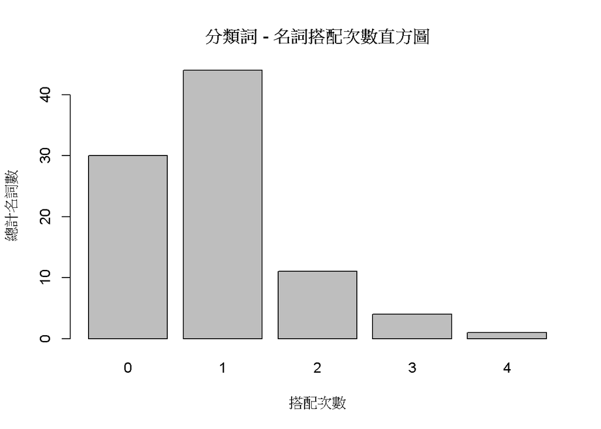

其中有搭配2,3或4個分類詞的名詞是心, 土地, 門, 床, 神經, 手指, 果實, 子彈, 香煙, 西瓜, 木板, 梅花, 流星, 病床, 氣球, 冰棒。

再來檢視由何萬順等人認定，表徵物件形狀的分類詞，與田意民等人選用名詞的搭配次數分佈狀況。

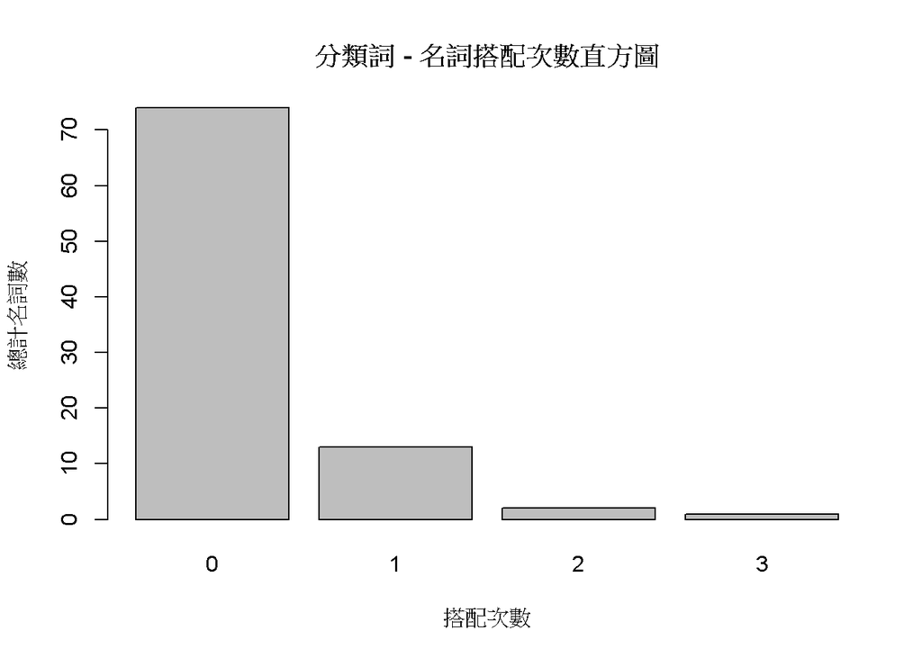

其中有搭配2或3個分類詞的名詞是玫瑰, 骨頭, 梅花。

### 形狀表徵分類詞語料整理

匯入分類詞片語檔案，整理目標研究未收錄的名詞數量。

```
## # A tibble: 24 x 3
##    WORD  N     THT
##    <chr> <chr> <chr>
##  1 個    2274  "V"
##  2 根    136   "V"
##  3 顆    221   "V"
##  4 粒    52    "V"
##  5 面    64    "V"
##  6 片    399   "V"
##  7 條    428   "V"
##  8 張    299   "V"
##  9 枝    41    "V"
## 10 瓣    7     ""
## 11 點    321   ""
## 12 頂    35    ""
## 13 朵    48    ""
## 14 封    50    ""
## 15 幅    119   ""
## 16 節    7     ""
## 17 具    79    ""
## 18 卷    21    ""
## 19 塊    258   ""
## 20 枚    80    ""
## 21 葉    6     ""
## 22 幀    6     ""
## 23 尊    29    ""
## 24 座    251   ""
```

檢視納入的分類詞的候選名詞，分類詞「點」的物件名詞都是指稱無具體形狀的事物，因此決定捨棄。其他五項分類詞選出的名詞表列如下：

```
## # A tibble: 1 x 5
##   幅              具              塊              枚              座
##   <chr>           <chr>           <chr>           <chr>           <chr>
## 1 人物畫,山水畫,太極圖,水墨~ 引擎,手榴彈,木乃伊,石棺,~ 大餅,手帕,月餅,木牌,火柴~ 人造衛星,水晶,火箭,印章,~ 大砲,大廈,大樓,小島,公~
```

以上表格儲存於“sti_table.csv”之內。